# Inteligencia Artificial Generativa (AI Gen)

Universidad Austral

Modelado de un Multi-Layer Perceptron (MLP)

Autor: Paulo Veiga, Claudio Righetti, Marco Sorondo  
Última modificación: 2026-08-21

[figure not shown]

01Qué se diseña de verdad 02Modelar la entrada 03Partir el dataset 04Modelar la salida 05La loss function 06Backpropagation 07Medir un clasificador 08Capas ocultas

01

Qué se diseña de verdad

Qué se diseña de verdad

## La red ve una fila de números

Todo lo que entra a una red es una fila de números de largo fijo, todos del mismo tipo (float). Esa fila es el único acceso que la red tiene al problema.

### Todo entra como números

Un cliente, una máquina, una foto o un contrato llegan a la red como un vector de floats de tamaño fijo. La semántica original desaparece en la codificación.

### El input es una traducción

Como toda traducción, puede perder cosas. Si lo que importa no quedó en esa fila, o quedó de una forma que borra su estructura, ninguna arquitectura lo recupera después.

### El error de codificación entra silencioso

La red solo ve floats y no puede detectar que una posición era un código y otra una cantidad. Nadie recibe una excepción: el modelo entrena, converge y se equivoca.

Qué se diseña de verdad

## El dato decide la arquitectura

Cada tipo de dato tiene una **forma natural**: cuántos ejes necesita para no perder información. Esa forma es la que decide qué arquitectura le corresponde, y no al revés.

- **La forma viene con el dato**: Es cuántos ejes necesita para no perder información, y no se elige: una tabla es una fila, una imagen es una grilla.
- **La arquitectura sí se elige**: Y se elige para aprovechar esa forma, no al revés.
- **Por eso el caso de esta clase es la tabla**: Ya viene como un MLP la espera; los otros tres habría que aplanarlos, y al aplanar se pierde la vecindad.

[figure not shown]

Qué se diseña de verdad

“

**Multi-Layer Perceptron**, o perceptrón multicapa: una capa de entrada, una o más capas ocultas donde cada neurona se conecta con todas las de la capa anterior (de ahí el nombre "densa", o *fully connected*), y una capa de salida.

Qué se diseña de verdad

## Una neurona, en una línea

Una capa hace dos cosas: una combinación lineal y una no linealidad.

1

La neurona recibe las entradas `x` y calcula la **pre-activación** `z = W·x + b`: una combinación lineal de las entradas más un sesgo.

2

Ese `z` pasa por la **activación** `a = f(z)`, y `a` es lo que la neurona entrega a la capa siguiente.

3

La no linealidad de `f` es lo que hace que apilar capas sirva. Sin ella, la composición de capas lineales colapsa a una sola matriz.

4

[figure not shown]

Qué se diseña de verdad

## Lo que hay que diseñar

Diseñar un MLP son seis decisiones, y la que todos creen que es la principal, cuántas capas ponerle, es la que menos pesa. Son las seis que recorre esta clase, en este orden.

### La entrada

Cómo cada variable se convierte en floats. Donde se gana o se pierde el modelo.

### El dataset

Cómo se parte en train, validación y test. Sin esto ninguna métrica es honesta.

### La salida

Cuántas neuronas y qué activación lleva la última capa. No se elige: la determina la tarea.

### La loss function

La fórmula que convierte una predicción equivocada en un número. Viene junto con la salida.

### El error

Cómo se mide que el modelo sirve, ya entrenado. Ningún número sirve para todos los casos.

### # Capas & # Neuronas

Lo único que se elige libremente, y lo que menos impacto tiene en el resultado.

Qué se diseña de verdad

## Del dato a los nodos de entrada

[figure not shown]

01Qué se diseña de verdad 02Modelar la entrada 03Partir el dataset 04Modelar la salida 05La loss function 06Backpropagation 07Medir un clasificador 08Capas ocultas

02

Modelar la entrada

Modelar la entrada

## Qué significa que el dato sea tabular

Esta clase modela datos tabulares: una fila por ejemplo y una columna por variable, sin vecindad ni orden intrínseco entre las columnas.

### Filas y columnas

Una fila por ejemplo y una columna por variable. Intercambiar edad con ingreso no cambia el dato mientras cada columna conserve su nombre.

### Por qué encaja un MLP

Una capa densa conecta cada neurona con todas las entradas y no usa la posición, así que el orden de las columnas no le quita información.

### En una imagen no pasa

Ahí la posición del píxel es parte del dato, y por eso el aplanado pierde algo que en tabular no existe.

[figure not shown]

Modelar la entrada

## La pregunta que decide la codificación

Frente a cualquier variable, una sola pregunta ordena la decisión: ¿qué significa la resta entre dos valores?

### Da una cantidad interpretable

85 m² menos 60 m² son 25 m² reales. Un float normalizado, una neurona.

### Da orden pero no magnitud

Satisfacción 4 menos 2. Ordinal; evaluar también one-hot.

### No significa nada

Barrio 14 menos barrio 7. One-hot o embedding según cuántos valores haya.

### No se puede ni plantear

Probablemente no sea una feature útil.

**Poner un número real en el vector es afirmar algo.** Cada float le promete a la red que las diferencias son comparables y que la magnitud escala el efecto, porque el aporte a `z = W·x + b` es el peso por el valor. Con 85 m² y 60 m² la promesa se cumple; con barrio 14 y barrio 7 es falsa, y ahí es donde hay que cambiar de codificación.

Todo termina en floats, nunca en enteros. Los enteros aparecen en un solo lugar: como índice para buscar una fila en una tabla de embeddings. **El entero no entra a la red, entra al lookup.**

Modelar la entrada

## Numéricas: normalizar no es opcional

Normalizar es reexpresar una variable en una escala comparable con las demás antes de que entre a la red. Cambia la unidad en la que se lee el número, no la información que trae. Aplica a las numéricas con magnitud real.

### z-score por defecto

`(x − μ) / σ`. El valor se lee como cuántos desvíos por encima o por debajo del promedio; la unidad original desaparece.

### log antes del z-score con colas largas

Ingresos, transacciones, días desde la última compra. La diferencia entre 1 y 10 importa más que entre 4000 y 4010.

### Los booleanos y one-hot no se tocan

Ya están en 0 y 1.

### Escala pareja no es importancia pareja

Normalizar no le quita peso a una variable; la importancia la aprenden los pesos. Solo la pone en condiciones de ser evaluada.

Modelar la entrada

## Categóricas: one-hot contra embedding

Una categoría sin orden se codifica de dos formas, y la cardinalidad decide cuál.

CriterioOne-hot · cardinalidad bajaEmbedding · cardinalidad alta

Qué entra al vector`k` floats: uno por categoría, todos en 0 salvo uno en 1`d` floats: **una fila**, la que le toca a la categoría

Qué es esa matriz`W`, los pesos de la primera capa — no es una entradaLa tabla `k × d`, entrenable, dentro de la red — tampoco es una entrada

Distancia entre categoríasTodas equidistantes — la verdad del datoLa red la aprende de los datos

Se aprendeNo; es interpretable y necesita pocos datosSí; la tabla **es** la primera capa

Con 500 barrios500 floats24 floats con `d = 24`

**La regla de la cardinalidad**: Hasta 15 valores, one-hot; de 15 a 50, cualquiera; 50 o más, embedding.

**La matriz nunca es la entrada**: Ni `W` ni la tabla de embeddings entran al vector: las dos son pesos de la red. Al vector entra `k` floats con one-hot y `d` con embedding.

[figure not shown]

Modelar la entrada

## Errores de codificación caros

Casi todos entran silenciosos: el modelo entrena sin dar error y falla en producción.

### Código como número

Un identificador de categoría cargado como entero. Con barrio 7 y 14 la red asume que 14 es el doble. Van como one-hot o embedding.

### Identificador único como feature

Una columna que no se repite entre ejemplos: DNI, CUIT, número de póliza. No hay nada que generalizar. Se descarta.

### Variable cíclica aplastada

Una magnitud que vuelve a empezar, codificada como número plano. Las 23:00 y las 00:00 quedan a 23. Van `sin(2πt/T)` y `cos(2πt/T)`.

### Faltante rellenado con 0

Un hueco tapado con un valor que la red no distingue de un dato real. Imputar media o mediana más un flag binario.

Modelar la entrada

## La tabla de decisiones

Cada fila es un tipo de variable, y la columna del medio es la única decisión. `k` es la cantidad de valores distintos; `d` es la dimensión del embedding, que se elige.

Variable¿Qué es?EjemploCodificación# de inputs (floats)

BooleanaDos valores, sí o noTiene cochera0 o 1, tal cual1

Numérica con magnitudNúmero en un rango parejoSuperficie 85 m²z-score `(x − μ)/σ`1

Numérica con cola largaNúmero con pocos valores enormesIngreso mensual`log(1+x)` y después z-score1

OrdinalCategorías con orden, sin distanciaPlan Free a EnterpriseFloat 0, 0.5, 1 más one-hot1 + k

Nominal, cardinalidad bajaCategorías sin orden, pocasTipo de viviendaOne-hotk

Nominal, cardinalidad altaCategorías sin orden, muchasBarrio (500 valores)Embedding de dimensión dd

Código con forma de númeroEtiqueta escrita como númeroCódigo postalEmbedding, nunca como númerod

Identificador únicoDistinto en cada filaDNI, CUITSe descarta0

CíclicaMagnitud que vuelve a empezarHora del día, mes de venta`sin(2πt/T)` y `cos(2πt/T)`2

FechaUn instante: ciclo más antigüedadFecha de altaCíclica más continua2 por ciclo + 1

Texto libreFrases sin vocabulario fijoReseña, descripciónSentence transformerd

**Corrido, tipo por tipo**: Cada fila de esta tabla esta entrenada — con su forma incorrecta al lado — en [`input-data-types.ipynb`](https://github.com/austral-ing-ai/talksmith-ing/blob/main/missions/mlp/input-data-types.ipynb).

01Qué se diseña de verdad 02Modelar la entrada 03Partir el dataset 04Modelar la salida 05La loss function 06Backpropagation 07Medir un clasificador 08Capas ocultas

03

Partir el dataset

Partir el dataset

## Un dataset, tres trabajos distintos

Partir el dataset es reservar de antemano tres porciones separadas, cada una con un trabajo distinto. Si medís el modelo con los mismos datos con los que lo entrenaste, la métrica miente.

### Train

La muestra con la que se ajusta el modelo. Es la única que actualiza `W` y `b`.

### Validación

Evaluación frecuente durante el entrenamiento, para tunear hiperparámetros y decidir cuándo cortar. El modelo la ve cada epoch y nunca entrena con ella. También se la llama dev set.

### Test

Se abre una sola vez, con el modelo ya terminado. Es la lectura más cercana al desempeño en producción.

Partir el dataset

## Los tres, lado a lado

CriterioTrainValidaciónTest

Para qué sirveEl modelo aprende de élTuning, early stopping, elegir modeloEvaluación final sin sesgo

Cuándo lo ve el modeloCada epochCada epoch, nunca entrena con élUna vez, al final

Actualiza los pesosSíNoNo

AugmentationSíNoNo

Proporción típica70%20%10%

La diferencia sutil está entre validación y test. El modelo no entrena con ninguno; la diferencia sos vos, que tomás decisiones mirando validación y vas sobreajustando tus elecciones a ese conjunto. **Por eso no alcanza con partir en dos:** el split de dos vías sirve solo si no tomás ninguna decisión iterativa, que no describe a ningún proyecto real.

Partir el dataset

## Todo se aprende solo del train

Las estadísticas de normalización se calculan **solo** con el train, y se guardan para reaplicarlas idénticas en validación, test y producción.

**Calcularlas sobre todo el dataset es data leakage:** información del test se filtra al entrenamiento y la métrica sale optimista.

**Y el bug es silencioso.** Normalizar en producción con μ=120 en vez de 95 no lanza ninguna excepción: solo devuelve predicciones incorrectas.

Python

```python
# MAL: μ y σ contaminados con el test (data leakage)
scaler.fit_transform(X_test)

# BIEN: μ y σ aprendidos solo del train
scaler.fit(X_train)
scaler.transform(X_test)
```

Partir el dataset

## Los errores que arruinan la medición

Ninguno lanza una excepción. Todos devuelven una métrica mejor que la real.

### Duplicados repartidos entre conjuntos

El mismo caso cae en train y en test. El test deja de medir generalización y mide memoria. Se deduplica antes de partir.

### No estratificar con clases desbalanceadas

El azar reparte sin mirar la clase. Con 2% de fraude el test puede quedar con tres positivos, y eso no es una métrica.

### Partir al azar una serie de tiempo

El azar pone futuro en train y pasado en test: el modelo predice enero mirando marzo. El número se ve espectacular y no se sostiene. Se corta por fecha.

### Achicar validación y test

Dejar 90% en train deja la métrica tan ruidosa que el peor modelo puede parecer mejor. Piso: unos cientos por conjunto.

Fuente: Jacob Solawetz (Roboflow), [Train, Validation, Test Split Explained (with Ratios)](https://blog.roboflow.com/train-test-split/) (2026); Tarang Shah, [About Train, Validation and Test Sets in Machine Learning](https://tarangshah.com/blog/2017-12-03/train-validation-and-test-sets/) (2017). Estratificación y partición temporal son aporte del docente.

Partir el dataset

## Qué hacer y qué no

La sección en reglas operativas. A la izquierda lo que hay que hacer siempre; a la derecha lo que más se ve mal resuelto.

### Qué hacer

- Partir antes de explorar
- Partir por grupo, no por fila
- Fijar la semilla y guardar el split
- Augmentation solo en train

### Qué no hacer

- Tunear contra el test
- Volver a partir porque el número no cerró
- Confiar en el corte por defecto

01Qué se diseña de verdad 02Modelar la entrada 03Partir el dataset 04Modelar la salida 05La loss function 06Backpropagation 07Medir un clasificador 08Capas ocultas

04

Modelar la salida

Modelar la salida

## Un catálogo para elegir sin dudar

Casi cualquier tarea entra en esta tabla. Elegida la fila, la salida queda determinada.

Qué prediceNeuronasActivaciónLoss

Un real (precio)1LinealMSE / MAE / Huber

Sí o no (churn)1SigmoideBCE

Una de N clasesNSoftmaxCross-entropy

Varias de N (tags)NSigmoide ×NBCE

Conteo (demanda)1Softplus / expPoisson NLL

Percentiles (P10/50/90)3, uno por percentilLinealPinball

Distribución (μ, σ)2μ lineal, σ softplusNLL gaussiana

Cuando el negocio necesita un rango y no un punto, los percentiles (P10, P50, P90) son lo más rentable: no asumen forma y dan el intervalo directo.

**Corrido, tarea por tarea**: Las siete familias estan entrenadas — con su forma incorrecta al lado — en [`output-layer-types.ipynb`](https://github.com/austral-ing-ai/talksmith-ing/blob/main/missions/mlp/output-layer-types.ipynb).

Modelar la salida

## La capa de salida la determina la tarea

Las cuatro representaciones se comparan por su forma, rango e interpretación.

### Lineal (ninguna)

`y = z` · todo ℝ · precio.

### Sigmoide

`σ(z) = 1 / (1 + e⁻ᶻ)` · (0, 1) · probabilidad de churn.

### Softmax

`eᶻⁱ / Σⱼeᶻʲ` · vector que suma 1 · clase de una imagen.

### Softplus

`log(1 + eᶻ)` · (0, ∞) · demanda o desvío.

Modelar la salida

## Cómo se ven las cuatro

La tabla del catálogo dice el rango; el dibujo dice la forma. Es lo que hace evidente por qué cada una sirve para lo que sirve.

### Lineal

La recta `y = z`. Sin piso ni techo, y por eso sirve para un precio: cualquier real es válido.

### Sigmoide

Aplasta cualquier número en (0, 1). El techo en 1 la convierte en una probabilidad.

### Softplus

Piso en 0 y sin techo. La forma correcta para un conteo o un desvío, que no pueden ser negativos.

### Softmax

No transforma un valor: reparte 1 entre N clases que compiten. Necesita ver todas las salidas a la vez.

[figure not shown]

01Qué se diseña de verdad 02Modelar la entrada 03Partir el dataset 04Modelar la salida 05La loss function 06Backpropagation 07Medir un clasificador 08Capas ocultas

05

La loss function

La loss function

“

La IA es el diseño de agentes racionales: sistemas que perciben su entorno y toman acciones para maximizar sus posibilidades de éxito en un objetivo dado. Resolver problemas complejos con matemáticas a gran escala, en lugar de crear humanos sintéticos.

La loss function

## Loss, cost y objective

Una **loss function** es la fórmula que convierte una predicción equivocada en un número — el único que la red intenta bajar, y del que sale el gradiente que corrige cada peso. Pero alrededor de ese número hay **tres** que se usan como sinónimos y no lo son.

La loss no se elige libre: viene con la salida. Para predecir un precio la tarea pide una neurona sin activación, porque el valor puede ser cualquier número real, y sobre esa salida van MSE, MAE o Huber. Cambiar la activación de salida obliga a cambiar la loss, y al revés.

### Loss

El error de un solo ejemplo. Es lo que mide la fórmula que elegimos acá.

### Cost

El promedio del loss sobre un batch o sobre el dataset. Es el número que el entrenamiento reporta.

### Objective

El cost más los términos de regularización, cuando las hay. Es lo que el optimizador minimiza de verdad, y la sección 6 muestra cuáles son, una vez que el gradiente esté sobre la mesa.

La loss function

## Regresión: MSE, MAE y Huber

Salida de una neurona con activación lineal. Las tres losses miden lo mismo, la distancia entre `y` y `t`, y se diferencian en cuánto castigan un error grande.

### MSE (error cuadrático medio)

`L = (y − t)²`. Castiga el error al cuadrado, así que un ejemplo muy lejos aporta más gradiente que cien ejemplos cerca. Es el default de regresión y la opción correcta cuando los valores raros son datos legítimos.

### MAE (error absoluto medio)

`L = |y − t|`. Castiga proporcional al error, así que un outlier pesa como un ejemplo más. Es la opción cuando los valores raros son ruido o errores de carga.

### Huber

Cuadrática mientras `|y − t| ≤ d` y lineal a partir de ahí. Se queda con el gradiente suave de MSE cerca del cero y con la resistencia de MAE lejos. `d` es un hiperparámetro.

[figure not shown]

La loss function

## Clasificación binaria: BCE

Salida de una neurona con sigmoide, o sea una probabilidad entre 0 y 1. La **binary cross-entropy** castiga según cuánta probabilidad le dio la red a la respuesta correcta: `L = −[ t · log(y) + (1 − t) · log(1 − y) ]`.

### Siempre queda un solo término vivo

Con `t = 1` sobrevive el primer término y la penalización es `−log(y)`; con `t = 0` sobrevive el segundo y es `−log(1 − y)`. `t` vale 0 o 1, así que el otro se multiplica por cero y desaparece.

### La confianza equivocada es lo caro

Decir 0,5 y errar cuesta poco; decir 0,01 y errar cuesta muchísimo. Es lo que empuja a la red a calibrar y no solo a acertar el lado.

### Con logits crudos hay que convertir al predecir

`prob = keras.ops.sigmoid(model(x))`. Un logit de 2,3 no es una probabilidad.

[figure not shown]

La loss function

## Clasificación multiclase: cross-entropy

Salida de N neuronas con softmax, o sea un vector de probabilidades que suma 1. La **cross-entropy** mira una sola casilla de ese vector, la de la clase verdadera, y castiga `−log` de esa probabilidad: `L = −log(y_c)`, donde `c` es la clase correcta.

### Las clases compiten

Softmax reparte una única unidad de probabilidad, así que subir una clase baja las otras. Es correcto cuando las etiquetas son excluyentes.

### El softmax puede ir adentro

`CategoricalCrossentropy(from_logits=True)` recibe logits crudos y aplica el softmax adentro, igual que su hermana binaria. Con etiquetas enteras en vez de one-hot, `SparseCategoricalCrossentropy`.

### Etiquetas no excluyentes rompen el modelado

Un ticket puede ser urgente y de facturación al mismo tiempo. Ahí van N sigmoides con BCE, porque forzar competencia entre etiquetas compatibles está mal desde el diseño.

[figure not shown]

La loss function

## Las especializadas, para tener ubicadas

Tres casos donde la loss de siempre da resultados malos de una forma que no se nota. Alcanza con reconocer cuándo buscarlas.

Qué prediceSalidaLossPor qué la de siempre falla

Un conteo (demanda, visitas)1 neurona, softplus o expPoisson NLLLineal con MSE predice conteos negativos y asume varianza constante, cuando en un conteo a mayor media hay mayor varianza

Un rango (P10, P50, P90)k neuronas linealesPinballUn valor puntual no responde la pregunta cuando la decisión depende del peor escenario

Una distribución (μ, σ)2 neuronas, μ lineal y σ softplusNLL gaussianaPredecir la media sola tira a la basura cuánta incertidumbre hay

**Los percentiles son los más rentables de los tres.** No asumen forma de la distribución, dan directamente el intervalo que el negocio pide y se implementan en pocas líneas con pinball loss. El detalle que muerde: hay que forzar que los percentiles no se crucen.

La loss function

## Percentiles: la pinball loss

Ninguna columna del dataset dice cuál es el P90. Cada ejemplo trae **un solo número**, el valor que efectivamente pasó. Lo que decide si la red aprende el promedio, la mediana o el P90 **es la loss, y nada más**: `L = max( q · (t − y), (q − 1) · (t − y) )`.

### Cada loss tiene su estadístico

El valor que minimiza MSE es **el promedio**; el que minimiza MAE es **la mediana**; el que minimiza pinball con `q` es **el percentil `q`**. Es una propiedad de la fórmula, no una intención de quien entrena.

### La asimetría es todo el mecanismo

Con `q = 0,9`, quedarse corto cuesta nueve veces más que pasarse. A la red le conviene subir la predicción hasta que solo el 10% de los casos le queden por encima — que es, por definición, el P90.

### MAE es pinball con `q = 0,5`

Los dos lados pesan igual y el mínimo cae en la mediana. No son dos losses distintas: MAE es el caso simétrico de la familia.

### Una neurona por percentil pedido

Con P10, P50 y P90 la última capa tiene tres neuronas lineales, cada una entrenada con su propio `q` contra el mismo objetivo.

[figure not shown]

01Qué se diseña de verdad 02Modelar la entrada 03Partir el dataset 04Modelar la salida 05La loss function 06Backpropagation 07Medir un clasificador 08Capas ocultas

06

Backpropagation

Backpropagation

## Buscar el mínimo de una función

Antes del algoritmo, la idea que lo ordena todo. Fijado el dataset, la loss depende **solo de los pesos**: cambiar un peso cambia el error. Eso dibuja una superficie, y entrenar es caminar por ella hacia abajo.

### La loss es una función de los pesos

El dataset está fijo, así que lo único que puede cambiar el error es `W` y `b`. La superficie del dibujo es esa dependencia.

### No hay fórmula que salte al mínimo

Se arranca en un punto al azar y se llega caminando, paso a paso. Por eso entrenar lleva tiempo.

### El gradiente es la brújula

Indica hacia dónde el error *sube* más rápido. El paso va justo en la dirección contraria, y de ahí sale el signo menos de todas las fórmulas que siguen.

### Backpropagation es cómo se calcula

No cambia la idea: es el procedimiento que consigue el gradiente de millones de pesos sin rehacer la cuenta para cada uno.

**Todo lo que viene son los detalles de este dibujo.** Qué función se deriva, cómo se calcula la dirección, y en qué momento exacto se da el paso.

[figure not shown]

Backpropagation

## Qué es backpropagation, y de dónde salió

Backpropagation es el algoritmo que consigue la brújula: dado el error al final de la red, calcula de cuánto es culpable **cada uno** de los pesos, todos en una sola pasada hacia atrás.

### La alternativa ingenua sería tantear

Mover un peso, volver a correr la red entera, ver cuánto cambió el error, y repetir. Una corrida completa **por cada peso**, millones de corridas para dar **un solo** paso de entrenamiento.

### Backprop consigue lo mismo en una ida y una vuelta

Ese factor es la diferencia entre entrenable y no entrenable, y es lo que hace posible entrenar una red grande.

### 1986 — Rumelhart, Hinton y Williams

*"Learning representations by back-propagating errors"*, en Nature. No lo inventan — la técnica ya existía: muestran que **funciona**, y que las capas ocultas aprenden representaciones útiles por su cuenta. Ahí arranca todo lo demás.

### Hoy nadie lo programa a mano

Lo que en los frameworks se llama *autograd* o *gradient tape* es este mismo algoritmo, automatizado, y es literalmente lo que corre adentro de `model.fit`.

Backpropagation

## Entrenar es un ciclo de dos movimientos

**Hacia adelante** la red calcula su predicción, una fila por vez. **Hacia atrás** reparte el error y deja anotado, en **valores intermedios**, cuánto contribuyó cada peso a equivocarse. Los pesos no se mueven todavía.

1

#### Propagación hacia adelante

Empujar una fila a través de la red hasta obtener `y`. Es la misma cuenta que hace el modelo ya entrenado cuando predice.

2

#### Propagación hacia atrás

Recorrer la red al revés calculando valores intermedios: la culpa de cada unidad y el gradiente de cada peso. Se **suman a un acumulador**; no se aplican.

3

#### La corrección, al cerrar el batch

Cuando todas las filas pasaron, se promedia el acumulador y ahí sí se corrigen `W` y `b`, una sola vez. Después arranca el batch siguiente.

[figure not shown]

Backpropagation

## El número que hay que derivar

Lo que hay que derivar es **la loss function**, y cuál es la fija la tarea. Tomemos un ejemplo: si la red predice el precio de una casa, la salida es una neurona lineal y la loss es el error cuadrático.

### Qué recorre la `Σ`

`y` es la predicción y `t` el objetivo. La suma es sobre las **unidades de salida de un ejemplo**, no sobre las filas del batch. Y acá la salida es **una sola neurona**, así que tiene un único término: `L = ½(y − t)²`. La `Σ` está por el caso general — N clases, N salidas — que es la notación con la que trabaja el resto de la sección.

### Al cuadrado

Los errores por exceso y por defecto dejan de cancelarse, y los grandes pesan más que los chicos. Es lo que separaba MSE de MAE.

### El factor ½

No mueve el mínimo. Está para que la derivada quede limpia: el 2 del exponente baja al derivar y se cancela contra él.

### Diferenciable

Es lo que permite calcular el gradiente y saber en qué dirección mover cada peso. Sin esta propiedad no hay algoritmo.

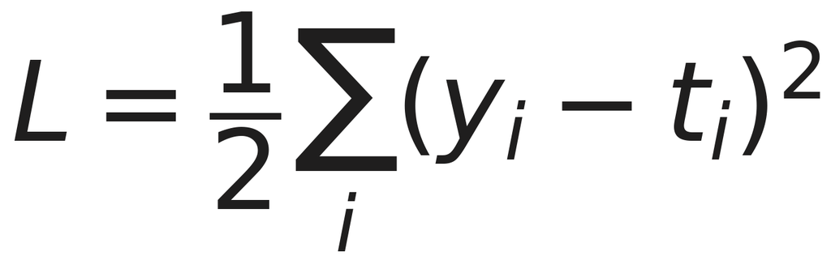

Backpropagation

## La regla de la cadena

La pregunta es concreta: **¿cuánto cambia el error si movemos un peso en particular?** El peso no toca el error directo: lo hace a través de la suma ponderada, y esta a través de la activación.

[figure not shown]

Backpropagation

## La misma cadena, en movimiento

El dibujo anterior muestra el camino; este video muestra el **empujón viajando por él**. Se mueve `w` un poquito y se ve el efecto bajar por la cadena — a la suma, a la activación, al error — que es exactamente lo que calcula la fórmula de tres factores.

- **Lo que agrega sobre el dibujo**: La derivada deja de ser una fórmula y pasa a ser una pregunta física: si empujo esto tanto, ¿cuánto se mueve aquello? Cada barra que se desplaza es uno de los tres factores.
- **La notación es otra, y hay que avisarlo antes**: Él escribe `C₀` donde nosotros escribimos `L`, y `a⁽ᴸ⁾` donde nosotros escribimos `y`. Su `y` es el objetivo, que para nosotros es `t`. El superíndice `⁽ᴸ⁾` es el número de capa, no la loss.
- **Y un 2 en vez del ½**: Su coste no lleva el factor ½, así que al derivar le queda un 2 adelante. La cuenta es la misma.
- **Termina donde estamos**: El último cuadro es la regla de la cadena encuadrada, con los mismos tres factores y en el mismo orden.

[video not shown]

Backpropagation

## Qué vale cada factor

La diapositiva anterior dijo **cuáles** son los tres factores. Esta dice **cuánto vale cada uno**, y los tres salen de cosas que ya están calculadas.

- **El error, si cambia la salida**: Con la loss cuadrática, la diferencia limpia: `yⱼ − tⱼ`. Es el único factor que se entera de qué loss elegiste.
- **La salida, si cambia la suma**: La derivada de la activación evaluada en ese punto: `f'(zⱼ)`. Si se aplana, el producto entero se va a cero.
- **La suma, si cambia el peso**: La entrada que multiplicaba a ese peso, nada más: `xᵢ`.
- **Los dos primeros se reusan**: ① y ② dependen de la unidad, no del peso: se calculan una vez por unidad y sirven para todos los pesos que llegan a ella. Una capa de 512×256 tiene 131.072 pesos y se resuelve con 256 cuentas.

**El gradiente de un peso es un producto de tres números que ya tenés.** Ninguno obliga a recorrer la red de nuevo, y esa es toda la eficiencia de backpropagation.

[figure not shown]

Backpropagation

## Una capa más atrás

Hasta acá seguimos un peso que llega **directo** a la unidad de salida. ¿Y un peso del medio, dos unidades de distancia del error? No hay que rehacer nada: la cadena se estira.

[figure not shown]

Backpropagation

## La tasa de aprendizaje η

Cerrado el batch y promediados los gradientes acumulados, corregir un peso es restarle una fracción de su gradiente. Cuánta es esa fracción lo fija la **tasa de aprendizaje `η`**, uno de los hiperparámetros más sensibles.

### El signo menos

El gradiente apunta hacia donde el error crece, así que el paso va en la dirección opuesta.

### `η` muy chico

El entrenamiento avanza, pero tan despacio que puede volverse impracticable.

### `η` muy grande

Los pasos se pasan del mínimo y el error oscila o diverge.

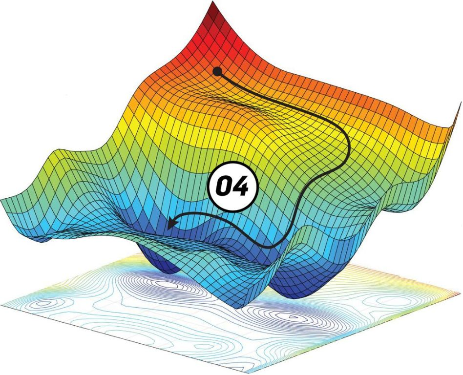

Backpropagation

## El learning rate es el paso

### El signo menos.

El gradiente apunta hacia donde el error crece, así que el paso va en la dirección opuesta.

### `η` muy chico.

El entrenamiento avanza, pero tan despacio que puede volverse impracticable.

### `η` muy grande.

Los pasos se pasan del mínimo y el error oscila o diverge.

[figure not shown]

Backpropagation

## Batch y época no son lo mismo

Los pesos no se ajustan ejemplo por ejemplo ni una sola vez por dataset. El train se parte en **batches** de tamaño fijo, y cada batch produce **un** ajuste.

### Batch

Un subconjunto de filas del train que entra junto. Las `B` filas hacen el forward a la vez con los mismos pesos, se promedia su loss, y ese promedio es lo que se deriva.

### Un ajuste por batch

No uno por fila ni uno por dataset: exactamente uno cada vez que se cierra un batch. Con 10.000 filas y batch de 100 son 100 ajustes por vuelta.

### Época

Una pasada completa por todo el train, o sea por todos sus batches.

**El tamaño del batch es un hiperparámetro.** No se aprende: lo elige quien entrena, y cambia cuántos ajustes entran en cada época.

[figure not shown]

Backpropagation

## El ciclo completo, batch a batch

Todo junto, y con el reloj a la vista: **dentro del batch se acumula, al cerrar el batch se aplica.** Por eso el batch size no cambia solo la velocidad — cambia cuántos ajustes entran en cada vuelta y cuánto ruido arrastra cada uno.

[figure not shown]

Backpropagation

## La función objetivo

Lo que el optimizador minimiza no es la loss: es la **función objetivo** `J`, que suma dos términos — el `cost`, que ya conocen, más una penalización por complejidad. Las tres primeras son formas distintas de escribir `R(w)`; la cuarta regulariza sin entrar en la fórmula.

### L2 — Ridge, o *weight decay*

Suma `λ Σ w²`. Su gradiente es `2λw`, así que el paso de la 6.9 le resta a cada peso una fracción de sí mismo: eso es literalmente el *decay* del nombre. Achica todos y ninguno llega a cero. Es el default.

### L1 — Lasso

Suma `λ Σ |w|`. Su gradiente es `λ·signo(w)`, un empujón del mismo tamaño sin importar cuán chico sea el peso — por eso llega a clavarlos en cero, y de ahí la selección de variables (*sparsity*).

### Elastic Net

Combina L1 y L2. Un poco de cada uno, para cuando ni la selección dura de L1 ni el achique parejo de L2 alcanzan solos.

### Dropout — el que queda afuera de `J`

No suma ningún término a la fórmula ni toca el gradiente: apaga neuronas al azar en cada forward del entrenamiento, así la red no puede depender de ninguna en particular. Regulariza rompiendo la coadaptación entre neuronas, no penalizando pesos. Solo actúa entrenando; en inferencia está apagado.

**El término entra al gradiente como cualquier otra parte de `J`.** Por eso en **cada paso de actualización** empuja los pesos hacia cero, además de hacia el mínimo del error — y por eso la diapositiva va acá y no en la sección de la loss: hasta que el gradiente y el paso no estuvieron sobre la mesa, no había con qué explicarlo.

Backpropagation

## Qué mirar cuando esto se entrena

En la práctica nadie mira las fórmulas: se mira la curva de loss y se toca alguna perilla. Este es el mapa de síntoma, causa y qué tocar.

Lo que vesQué suele serQué tocar

La loss no baja desde el arranque`η` demasiado chico, o el gradiente se desvanece antes de llegar a las primeras capasSubir `η` ×10; ReLU en las ocultas; revisar la inicialización

La loss oscila fuerte, o se va a `NaN``η` demasiado grande, o el gradiente explotaBajar `η` ÷10; `clipnorm` o `global_clipnorm`

La loss baja pero con mucho ruidoBatch chico: el promedio sale de pocas filas y el gradiente es ruidosoSubir el batch size

Train baja y validación subeOverfitting, no un problema de gradienteRegularizar, o parar antes

Una variable domina el ajusteCodificación de la entrada, no el gradienteSección 2

**Las perillas, en orden de impacto**: `η` primero y por lejos. Después el batch size. Después activación e inicialización. Último, capas y neuronas, que es lo que todos tocan primero. Y una perilla por vez.

01Qué se diseña de verdad 02Modelar la entrada 03Partir el dataset 04Modelar la salida 05La loss function 06Backpropagation 07Medir un clasificador 08Capas ocultas

07

Medir un clasificador

Medir un clasificador

## El 99% de accuracy que no sirve

Un detector de fraude sobre 10.000 transacciones, donde 100 son fraude. La regla más tonta posible: decir siempre que no es fraude.

### Accuracy la escribe la clase mayoritaria

Con 9.900 legítimas sobre 10.000, acertar "no es fraude" siempre da 99% sin haber aprendido nada.

### No todos los errores cuestan lo mismo

Un fraude no detectado y una alarma falsa no son intercambiables, y accuracy los suma como si lo fueran.

### Hace falta separar los tipos de error

Eso es exactamente lo que hace la matriz de confusión.

Medir un clasificador

## La matriz de confusión

Para clasificación binaria, todos los resultados caen en una tabla de 2×2 que cruza predicción y verdad.

### TP (verdadero positivo)

Era positivo y el modelo lo marcó. Acierto.

### FN (falso negativo)

Era positivo y el modelo lo dejó pasar. Lo más caro en fraude o diagnóstico.

### FP (falso positivo)

Era negativo y el modelo lo marcó. Falsa alarma.

### TN (verdadero negativo)

Era negativo y el modelo lo dejó pasar. Acierto.

Medir un clasificador

## Precision, recall y F1

De las cuatro celdas salen las métricas que de verdad describen a un clasificador.

### Precisión

De todo lo que el modelo marcó, ¿cuánto era de verdad?

Fórmula

`TP / (TP + FP)`. Sube cuando el modelo molesta poco con falsas alarmas.

Importa cuando el falso positivo es caro: mandar a spam un mail importante.

### Recall

De todo lo que había, ¿cuánto encontró?

Fórmula

`TP / (TP + FN)`. Sube cuando se escapan pocos.

Importa cuando el falso negativo es caro: no detectar una enfermedad o un fraude.

### F1

¿Y si las dos importan parecido?

Fórmula

`2 · (P · R) / (P + R)`, la media armónica. La manda el número más chico: con 0.9 y 0.5 el promedio da 0.70 y F1 da 0.64; con recall 0, F1 da 0.

Importa cuando ninguna de las dos alcanza sola, como el caso de churn del quiz.

Precisión y recall están en tensión: subir una suele bajar la otra. Qué priorizar lo decide el costo del error, no la matemática.

Medir un clasificador

## Quiz 1: el filtro de spam

Un filtro de spam. Bloquear un mail legítimo es peor que dejar pasar uno dudoso: el usuario perdona ver basura en la bandeja, no perdona perder una factura. ¿Qué métrica priorizás?

1. Precisión
2. Recall

Respuesta

Precisión. El error caro es el falso positivo, marcar como spam algo que no lo era.

Priorizar precisión significa que el filtro solo bloquea cuando está seguro, a costa de dejar pasar algo de spam.

Medir un clasificador

## Quiz 2: el test de una enfermedad grave

Un test para detectar una enfermedad grave y tratable. Dejar ir a una persona enferma es peor que pedirle estudios extra a una sana. ¿Qué métrica priorizás?

1. Precisión
2. Recall

Respuesta

Recall. El error caro es el falso negativo, no detectar a quien sí estaba enfermo.

Priorizar recall significa que el test marca ante la duda, a costa de mandar a estudios a gente sana.

Medir un clasificador

## Quiz 3: el modelo de churn

Un modelo que marca quién se va a dar de baja, y a cada marcado se le ofrece un descuento. Un descuento regalado a alguien que no se iba cuesta plata; un cliente que se va sin oferta también. ¿Qué métrica priorizás?

1. Precisión
2. Recall
3. F1

Respuesta

F1. Los dos errores cuestan parecido, así que optimizar una sola métrica deja la otra libre.

F1 es el número que las mantiene atadas, y por eso este es el caso donde sirve como número único.

Medir un clasificador

## El umbral, una perilla de negocio

Un clasificador binario no devuelve sí o no, devuelve una probabilidad. El umbral es el número que la convierte en decisión.

### El umbral es una perilla de negocio

Se mueve según cuál de los dos errores duele más. Dejarlo en 0.5 también es una decisión, no un default neutro.

### La curva precision-recall

Muestra ese intercambio para todos los umbrales de una vez, y sirve para comparar dos modelos sin fijar ninguno.

[figure not shown]

01Qué se diseña de verdad 02Modelar la entrada 03Partir el dataset 04Modelar la salida 05La loss function 06Backpropagation 07Medir un clasificador 08Capas ocultas

08

Capas ocultas

Capas ocultas

## Cuántas capas y cuánto ancho

Es la única decisión de la lista que se elige libremente, y la que menos impacto tiene. Conviene resolverla rápido con un punto de partida y corregir después mirando el error.

### Más ancho que la entrada

La primera capa oculta no debería ser más angosta que el vector de entrada, para no crear un cuello de botella que tire información antes de empezar.

### Potencia de 2 y decreciente

128, 64, 32 hacia la salida. La potencia de 2 es alineación de memoria; lo decreciente es que la red va comprimiendo hacia la respuesta.

### Lo que manda es la cantidad de datos

La relación que importa es parámetros contra filas de entrenamiento, no parámetros contra features.

### El procedimiento, no la fórmula

Empezar chico y mirar el error de **train**: si es alto, falta capacidad y hay que agrandar; si el train está bien y la validación mal, sobra capacidad y hay que achicar o regularizar.

**1 a 3 capas ocultas alcanzan para datos tabulares.** Si necesitás más profundidad que eso en una tabla, el problema casi nunca es la arquitectura.

Cuántos datos tenésPunto de partida

Cientos de filas1 capa de 8 a 16 neuronas

Miles1 o 2 capas de 32 a 64

Decenas de miles2 o 3 capas de 64 a 128

Capas ocultas

## Las activaciones ocultas, y cómo se ven

Una activación oculta es la función no lineal `f` que se aplica después de `z = W·x + b` en las capas del medio. Su trabajo no es acotar el resultado a un rango con sentido, como en la salida, sino romper la linealidad para que apilar capas sirva.

FunciónFórmula y rangoCuándo

ReLU`max(0, z)` — [0, ∞)El default de las capas ocultas

GELU / SiLUsuavizaciones de ReLU — (−0.3, ∞) aprox.Transformers

Tanh`(eᶻ − e⁻ᶻ) / (eᶻ + e⁻ᶻ)` — (−1, 1)Redes recurrentes, salidas centradas

Sigmoide`1 / (1 + e⁻ᶻ)` — (0, 1)Casi nunca en capas ocultas

La sigmoide y la tanh saturan: con `z` grande su derivada es casi cero, el gradiente que llega a las capas de abajo se apaga y la red deja de aprender. ReLU no satura del lado positivo, y esa es la razón por la que ganó.

[figure not shown]

Capas ocultas

## Cómo arrancan los pesos

Los pesos empiezan en valores al azar, pero **no en cualquier azar**. La escala de esa inicialización decide si la señal sobrevive al atravesar las capas o se apaga en el camino.

### Por qué no todos en cero

Si todas las neuronas de una capa arrancan iguales, calculan lo mismo y reciben el mismo gradiente: quedan idénticas para siempre. El azar es lo que las hace distintas.

### El efecto es multiplicativo

Si cada capa multiplica la escala por un factor `c`, tras 10 capas el efecto es `c¹⁰`. Con `c = 1.5` la señal se multiplica por 58; con `c = 0.5` se divide por 1.000.

### He para ReLU, Glorot para el resto

Las dos eligen la varianza de `W` para que `c` quede cerca de 1 al arrancar. **He** (o **Kaiming**) está pensada para ReLU; **Glorot** (o **Xavier**), para activaciones simétricas como tanh. Son el default de los frameworks, así que casi nunca hay que tocarlas.

### Un solo problema, cuatro herramientas

Normalizar la entrada, inicializar bien, normalizar entre capas (BatchNorm, LayerNorm) y recortar el gradiente atacan todos lo mismo: que la escala no se descontrole.

**Lo accionable es corto.** Dejá el default del framework, normalizá la entrada, y si el entrenamiento no arranca, revisá la inicialización antes de agregar capas.

Conclusiones

Conclusiones

## Lo que hay que llevarse

#### El diseño está en la entrada y la salida

La cantidad de capas importa poco; cómo se codifica cada variable y cómo se modela la respuesta es donde se gana o se pierde el modelo.

#### La red solo ve floats

Codificar mal es fatal porque el error entra silencioso. La pregunta de la resta ordena casi toda la decisión de codificación.

#### La partición decide si la métrica dice la verdad

Train para aprender, validación para decidir, test una sola vez al final. Y todo lo que se aprende de los datos, μ y σ incluidos, se aprende solo del train.

#### La loss viene con la salida

Elegida la tarea quedan determinadas las neuronas, la activación y la fórmula que mide el error. Esa fórmula tiene que ser diferenciable, y esa es la razón por la que nadie entrena directamente sobre accuracy.

#### El ajuste ocurre una vez por batch

El forward predice, el backward reparte la culpa capa por capa, y los pesos se corrigen recién cuando el batch entero terminó de procesarse. Una época son tantos ajustes como batches tenga el train.

#### Accuracy sola engaña

La matriz de confusión separa los tipos de error; precision, recall y F1 describen lo que accuracy esconde, y el umbral es una perilla de negocio.

#### Regularizar es bajar varianza a propósito

Primero se diagnostica el overfitting (brecha train-validación), después se trata: L2 de base, dropout en redes profundas, early stopping casi siempre.

Conclusiones

## Checklist operativo para la práctica

Para cada variable de un problema real, antes de tocar la red:

1

#### ¿Es número, categoría, ciclo, fecha o texto?

Define la familia de codificación.

2

#### ¿Qué significa la resta entre dos valores?

Decide float, ordinal, one-hot o embedding.

3

#### ¿Cuántos valores distintos tiene?

One-hot o embedding según la cardinalidad.

4

#### ¿Puede faltar, y faltar significa algo?

Imputación más flag, o categoría propia.

5

#### ¿La voy a tener al momento de predecir?

Si no, no es una feature.

Conclusiones

## Los notebooks de la clase

Todo lo que vimos esta corrido, con los numeros a la vista, en dos notebooks que trabajan **sobre las mismas 2000 casas**. Uno recorre la entrada y el otro la salida.

#### La entrada

[`input-data-types.ipynb`](https://github.com/austral-ing-ai/talksmith-ing/blob/main/missions/mlp/input-data-types.ipynb) · [abrir en Colab](https://colab.research.google.com/github/austral-ing-ai/talksmith-ing/blob/main/missions/mlp/input-data-types.ipynb) — tipo por tipo, la conversion a floats y cuantos ocupa cada uno. Cada codificacion incorrecta esta entrenada al lado de la correcta.

#### La salida

[`output-layer-types.ipynb`](https://github.com/austral-ing-ai/talksmith-ing/blob/main/missions/mlp/output-layer-types.ipynb) · [abrir en Colab](https://colab.research.google.com/github/austral-ing-ai/talksmith-ing/blob/main/missions/mlp/output-layer-types.ipynb) — las mismas casas, pero el precio pasa a ser **entrada** y se predice otra cosa. Una seccion por familia de salida, con su par activacion + loss.

#### El cuerpo de la red nunca cambia

Siete tareas con exactamente la misma red y la misma matriz de entrada. Lo unico que se mueve es la ultima capa. Es la tesis de la clase, corrida.

Girá el teléfono para ver las diapositivas